# Intro Open Data Science course - Nice project

ANgela KAtherine MArtin VIvanco

# Introduction to Open Data Science - Course Project

# **About the project**

*We want to use the RStudio interface to control git. I created a RStudio Project, I wrote stuff and I hope I’ll add some nice stat graphs :).*

*This course looks very interesting. But, I’m really worried now because my laptop broke down since friday. I hope I can recover my data.*

*update: one week later, the pc from my work is working, I recovered my data, but I do not trust it anymore :(

```r
# This is a so-called "R chunk" where you can write R code.
date()
```

```
## [1] "Thu Dec 03 23:22:58 2020"
```

REPOSITORY:

https://github.com/ANKAMAVI

“There is a pleasure in the pathless woods,  
There is a rapture on the lonely shore,  
There is society, where none intrudes,  
By the deep Sea, and music in its roar:  
I love not Man the less, but Nature more,  
From these our interviews, in which I steal  
From all I may be, or have been before,  
To mingle with the Universe, and feel  
What I can ne’er express, yet cannot all conceal.”  
by *Lord Byron*

```r
library(readr)
library(dplyr)
```

```r
library(corrplot)
library(GGally)
library(FactoMineR)
library(factoextra)
library(ggplot2)
library(tidyr)
library(MASS)
```

# **4. Dimensionality reduction techniques - week 5**

```r
date()
```

```
## [1] "Thu Dec 03 23:23:00 2020"
```

# 4.1 *Data overview*

Description of ‘human’ dataset variables.  
Original data from: http://hdr.undp.org/en/content/human-development-index-hdi  
Retrieved, modified and analyzed by Tuomo Nieminen 2017

The data combines several indicators from most countries in the world “Country” = Country name  
There are in total 8 variables explaining human development, considered here:

Related to health and knowledge:  
EDU.EDP: Expected years of schooling, LIFE.EXP: Life expectancy at birth, GNI: The gross national income Index, MAT.MOR: Maternal mortality, ADO.BIRTH: Adolescent birth ratio.

Related to empowerment:  
EDU2.F: Percentage of females having secondary education, LABO.F: Percentage of females being employed, PARLI.F: Female representation in parliament.

```r
human <- read_csv("http://s3.amazonaws.com/assets.datacamp.com/production/course_2218/datasets/human2.txt")
str(human)
```

```
## tibble [155 x 8] (S3: spec_tbl_df/tbl_df/tbl/data.frame)
##  $ Edu2.FM  : chr [1:155] "Norway" "Australia" "Switzerland" "Denmark" ...
##  $ Labo.FM  : num [1:155] 1.007 0.997 0.983 0.989 0.969 ...
##  $ Edu.Exp  : num [1:155] 0.891 0.819 0.825 0.884 0.829 ...
##  $ Life.Exp : num [1:155] 17.5 20.2 15.8 18.7 17.9 16.5 18.6 16.5 15.9 19.2 ...
##  $ GNI      : num [1:155] 81.6 82.4 83 80.2 81.6 80.9 80.9 79.1 82 81.8 ...
##  $ Mat.Mor  : num [1:155] 64992 42261 56431 44025 45435 ...
##  $ Ado.Birth: num [1:155] 4 6 6 5 6 7 9 28 11 8 ...
##  $ Parli.F  : num [1:155] 7.8 12.1 1.9 5.1 6.2 3.8 8.2 31 14.5 25.3 ...
##  - attr(*, "problems")= tibble [155 x 5] (S3: tbl_df/tbl/data.frame)
##   ..$ row     : int [1:155] 1 2 3 4 5 6 7 8 9 10 ...
##   ..$ col     : chr [1:155] NA NA NA NA ...
##   ..$ expected: chr [1:155] "8 columns" "8 columns" "8 columns" "8 columns" ...
##   ..$ actual  : chr [1:155] "9 columns" "9 columns" "9 columns" "9 columns" ...
##   ..$ file    : chr [1:155] "'http://s3.amazonaws.com/assets.datacamp.com/production/course_2218/datasets/human2.txt'" "'http://s3.amazonaws.com/assets.datacamp.com/production/course_2218/datasets/human2.txt'" "'http://s3.amazonaws.com/assets.datacamp.com/production/course_2218/datasets/human2.tx…
##  - attr(*, "spec")=
##   .. cols(
##   ..   Edu2.FM = col_character(),
##   ..   Labo.FM = col_double(),
##   ..   Edu.Exp = col_double(),
##   ..   Life.Exp = col_double(),
##   ..   GNI = col_double(),
##   ..   Mat.Mor = col_double(),
##   ..   Ado.Birth = col_double(),
##   ..   Parli.F = col_double()
##   .. )
```

Correlation between mentioned variables:

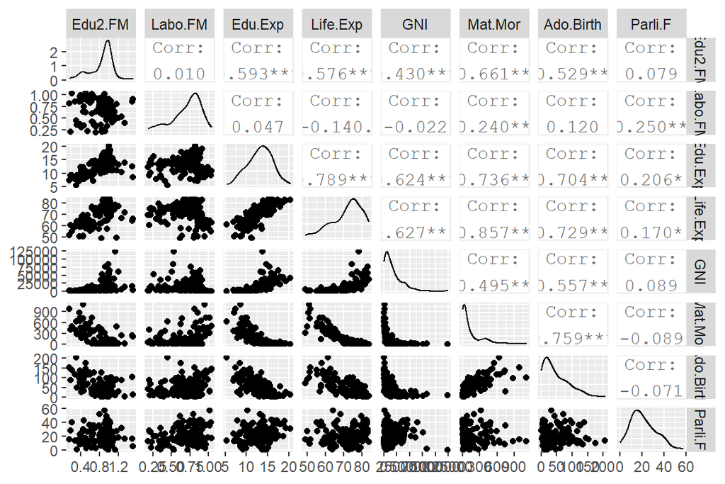

```r
human <- read.csv("~/GitHub/IODS-project/IODS-project/data_AKMV/human2.txt")
ggpairs(human)
```

# 4.2 *PCA* (PRINCIPAL COMPONENT ANALYSIS)

PCA raw data:

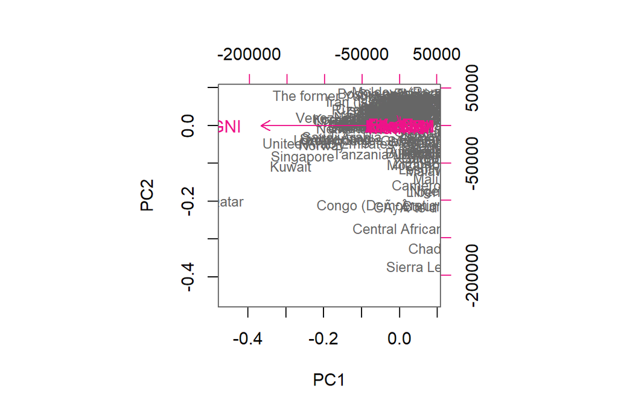

```r
human <- read.csv("~/GitHub/IODS-project/IODS-project/data_AKMV/human2.txt")
pca_human<-prcomp(human)
biplot(pca_human, choices = 1:2, cex = c(0.8, 1), col = c("grey40", "deeppink2"))
```

contribution to the dimensions:

[figure not shown]

```r
res.pca1 <- prcomp(human, center=TRUE, scale = TRUE)
fviz_pca_var(res.pca1, col.var = "contrib", # Color by contributions to the PC
             gradient.cols = c("#00AFBB", "#E7B800", "#FC4E07"),repel = TRUE, title="Not-standardized variables")
```

we can see that PC1 explains 53.6% of the systems while PC2 only 16.2%., the variables that better explain the system are: life expectancy, maternal mortality and education expectancy. Similarly in PC2 is the presence of working females.

PCA of standardized variables:

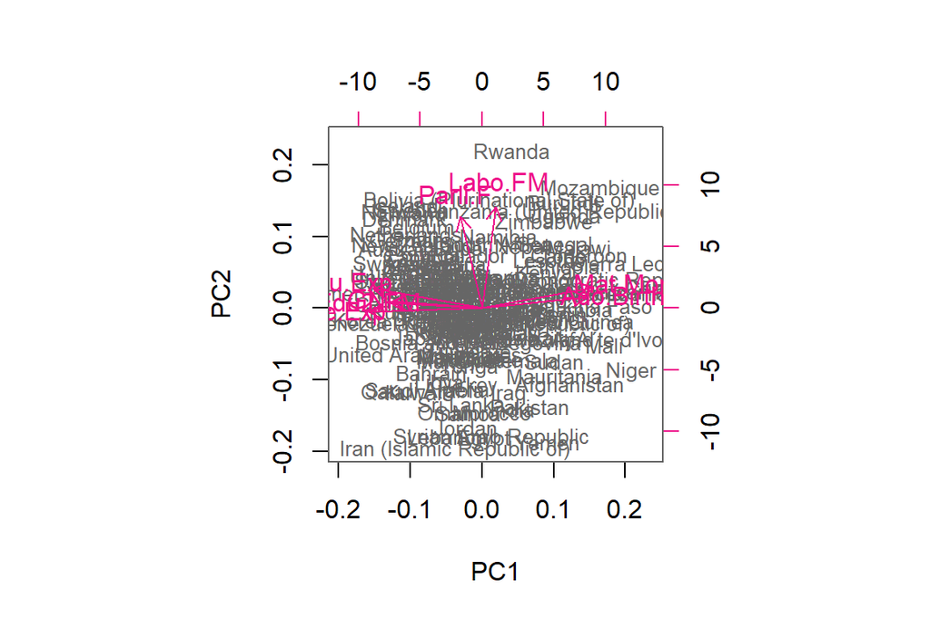

```r
human_std <- scale(human)
pca_human <- prcomp(human_std)
biplot(pca_human,repel=TRUE,  choices = 1:2, cex = c(0.8, 1), col = c("grey40", "deeppink2"))
```

contribution to the dimensions:

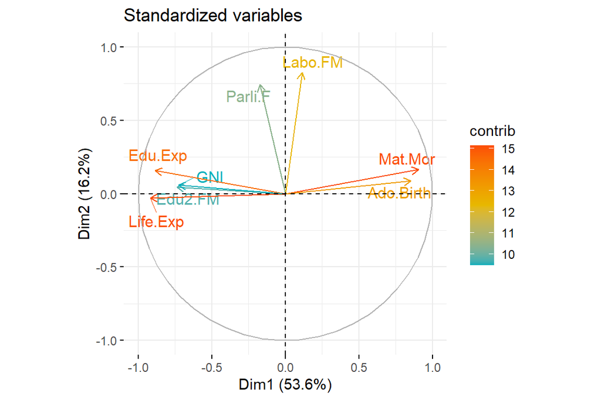

```r
res.pca <- prcomp(human_std, center=TRUE, scale = TRUE)
fviz_pca_var(res.pca, col.var = "contrib", # Color by contributions to the PC
             gradient.cols = c("#00AFBB", "#E7B800", "#FC4E07"),repel = TRUE, title="Standardized variables")
```